# Case 4intelligence

Carregando os pacotes usados

```r
library(vars)
library(tsDyn)
library(tidyverse)
library(readxl)
library(janitor)
library(lubridate)
library(rebus)
library(zoo)
library(urca)


library(sf)
library(geobr)
library(spData)
library(viridis)
library(gifski)
library(scales)
library(ggExtra)
library(ggtext)
library(ggthemes)
```

## Parte A

**2. Renomeie as colunas e as deixe na seguinte ordem: “data”, “var”, “setor” e colunas de localidades. Para essas últimas, utilize siglas (BR e siglas dos estados).**

```r
nomes_colunas <- c("data", "var", "setor", "br", "ce", "pe", "ba", "mg",
                   "es", "rj", "sp", "pr", "sc", "rs", "go", "df")

colnames(pmc) <- nomes_colunas
```

**3. Converta os valores das colunas de Brasil e UFs para que fiquem na classe numérica.**

```r
pmc <- pmc %>%
   mutate(across(.cols = br:df,
                .fns = ~ suppressWarnings(as.numeric(.x))))
```

**4. Substitua os textos na coluna “var”. Faça com que assumam apenas as palavras “volume” ou “receita”, a depender de cada linha.**

```r
pmc <- pmc %>%
  mutate(var = case_when(
           str_detect(var, pattern = "receita") ~ "receita",
           str_detect(var, pattern = "volume") ~ "volume"
         ))
```

**5. Converta a coluna “data” para que ela assuma a classe própria para data. O padrão deve ser YYYY-MM-DD. (Utilize 01 quando não houver especificado o dia).**

```r
meses <- readr::date_names_lang("pt")$mon

numero_mes <- as.character(1:12)

vetor_datas <- pmc$data

for (i in 1:12) {

  vetor_datas <- str_replace(vetor_datas,
                             pattern = meses[i],
                             replacement = paste0(numero_mes[i], "-"))
}

pmc$data <- vetor_datas

pmc <- pmc %>%
  mutate(data =
           str_remove_all(data, " ") %>%
           paste0("-01") %>%
           myd())

# obs.: warning referente às observações NA
```

**6. Para as colunas “data” e “var”, preencha os espaços contendo “NA” com a informação que não seja ”NA”localizada imediatamente acima.**

```r
pmc <- pmc %>% fill(data, var)
```

**7. Exclua todas as linhas em que a coluna “var” seja igual à “receita**

```r
pmc <- pmc %>%
  filter(var != "receita")
```

## Parte B

**1. Utilize visualizações e estatísticas para comparar o setor de Móveis e Eletrodomésticos com os outros setores. Como a sede da empresa é em São Paulo, verifique o comportamento neste estado. (Dê maior destaque para o período da pandemia).**

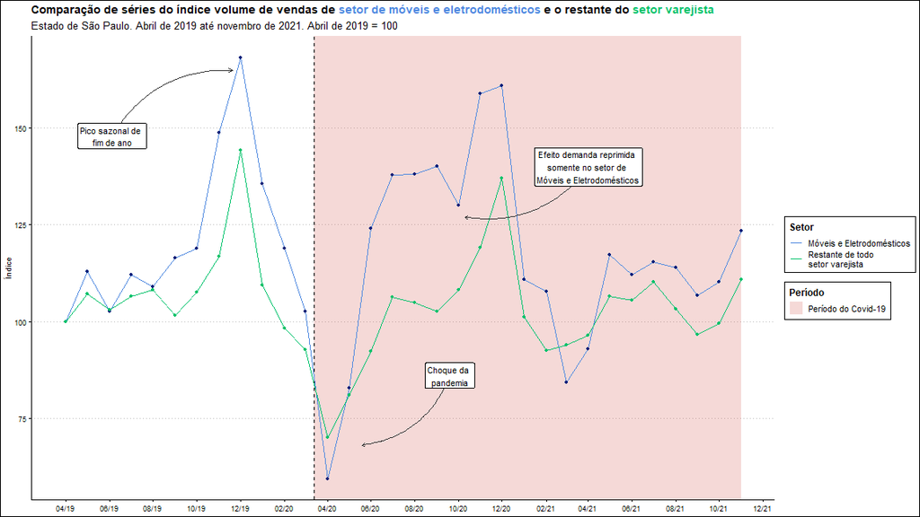

grafico

```r
pmc_geral <- pmc %>%
  filter(setor != "Móveis e eletrodomésticos",
         data >= "2019-04-01",
         data <= "2021-11-01") %>%
  group_by(data) %>%
  mutate(setor = "Todos",
         across(.cols = br:df,
                .fns = ~ mean(.x, na.rm = TRUE)),
         sp = sp / 81.01429 * 100)

pmc_moveis <- pmc %>%
  select(data, var, setor, sp) %>%
  pivot_wider(names_from = setor,
              values_from = sp) %>%
  filter(data >= "2019-04-01",
         data <= "2021-11-01") %>%
  mutate(`Móveis e eletrodomésticos`  = `Móveis e eletrodomésticos` / 79.1 *100)

arrows <- data.frame(
  x1 = c(as.Date("2019-06-05"),as.Date("2020-09-19"),  as.Date("2021-04-01")),
  y1 = c(148, 86, 140),
  x2 = c(as.Date("2019-11-20"),as.Date("2020-05-19"), as.Date("2020-10-10")),
  y2 = c(165, 68, 127)
)

p_serie_mov_varej <- ggplot() +
  geom_rect(aes(xmin = as.Date("2020-03-13"), xmax = as.Date("2021-11-01"),
                ymin = -Inf, ymax = Inf, fill = "covid"), alpha = 0.2)+
  geom_vline(xintercept = as.Date("2020-03-13"), linetype = "dashed")+
  geom_line(data = pmc_moveis, aes(data, `Móveis e eletrodomésticos`, color = "Moveis e Eletrodomesticos")) +
  geom_point(data = pmc_moveis, aes(data, `Móveis e eletrodomésticos`),
             color = "#01207a")+
  geom_line(data = pmc_geral,
            aes(data, sp, color = "Restante de todo \nsetor varejista"))+
  geom_point(data = pmc_geral, aes(data, sp), color = "#02c26b")+
  geom_curve(data = arrows,
             aes(x = x1, y =y1, xend = x2, yend = y2),
             curvature = -0.3,
             arrow = arrow(length = unit(0.07, "inch")),
             size = 0.4,
             color = "gray20")+
  annotate("label", label = "Pico sazonal de \nfim de ano",
           x = as.Date("2019-06-05"), y = 148)+
  annotate("label", label = "Choque da \npandemia",
           x = as.Date("2020-09-19"), y = 86)+
  annotate("label", label = "Efeito demanda reprimida \nsomente no setor de \nMóveis e Eletrodomésticos",
           x = as.Date("2021-04-01"), y = 140)+
  scale_x_date(date_labels = "%m/%y",
               date_breaks = "2 month",
               limits = as.Date(c('2019-03-31',"2021-11-01")))+
  scale_color_manual(name = "Setor", values = c("Moveis e Eletrodomesticos" = "#4f89e0", "Restante de todo \nsetor varejista" = "#02c26b"), labels = c("Móveis e Eletrodomésticos", "Restante de todo \nsetor varejista"))+
  scale_fill_manual(name = "Período", values = c("covid" = "#cf4238"), labels = c("Período do Covid-19"))+
  labs(title = "Comparação de séries do índice volume de vendas de <span style='color:#4f89e0;'>setor de móveis e eletrodomésticos</span> e o restante do <span style='color:#02c26b;'>setor varejista</span>",
       subtitle = "Estado de São Paulo. Abril de 2019 até novembro de 2021. Abril de 2019 = 100",
       x = NULL,
       y = "Índice")+
  ggthemes::theme_clean()+
  theme(
    plot.title = element_markdown(lineheight = 1.1)
  )

# TODO: gráfico ok

#obs.: gráfico melhor diagramado na imagem salva em png.

ggsave("graphics/grafico_serie_moveis_varejista.png", plot = p_serie_mov_varej, dpi = "screen", width = 16, height = 9)
```

No gráfico feito acima, percebe-se a sazonalidade no período de fim de ano para ambas as séries. Além disso, nos meses iniciais da pandemia (de março a maio), ambas as séries diminuem consideravelmente o volume de vendas. Contudo, o setor de Móveis e eletrodomésticos sofre uma alta a partir de junho de 2020 atípica, o que podemos considerar como efeito da demanda reprimida, ou algum outro fator a ser melhor estudado. O restante dos setores varejistas não sofre desse efeito, voltando ao patamar pré-pandemia.

**2. Compare visualmente o efeito da pandemia neste setor entre os estados. Observe diferenças na intensidade e no tempo para recuperação.**

Criarei um mapa animado em formato GIF para a visualização do índice de volume de vendas do setor de Móveis e Eletrodomésticos dentre os diferentes Estados, a cada mês. Para aumentar o poder explicativo, anexado ao mapa, haverá um gráfico em barras, indicando o valor preciso do índice para cada Estado.

```r
br_estados <- read_country(year = 2019, showProgress = FALSE)
```

```
## Using year 2019
```

```r
br_estados <- br_estados %>%
  mutate(abbrev_state = tolower(abbrev_state))


pmc_map1 <- pmc %>%
  filter(setor == "Móveis e eletrodomésticos",
         data >= "2019-04-01") %>%
  mutate(data = paste0(str_to_title(month(data, label = T)), " ", year(data))) %>%
  filter(!is.na(br))

vetor_datas <- pmc_map1$data

# Descobrir range para ajuste de escala do mapa

temp <- pmc_map1 %>%
  summarise(across(.cols = br:df,
                   .fns = ~ c(max(.), min(.))))
temp %>%
  rowwise() %>%
  summarise(max = max(c_across()),
            min = min(c_across()))
```

| max | min |
| --- | --- |
| 172.6 | 90.3 |
| 68.3 | 10.9 |

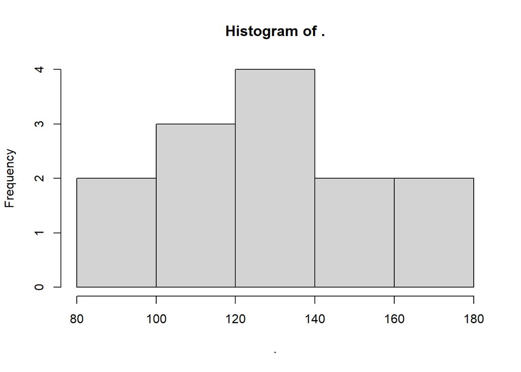

```r
# max = 172.6
# min = 10.9

# Criar histograma para avaliar se máximo e mínimo são outliers

as.numeric(temp[1,]) %>% hist()
```

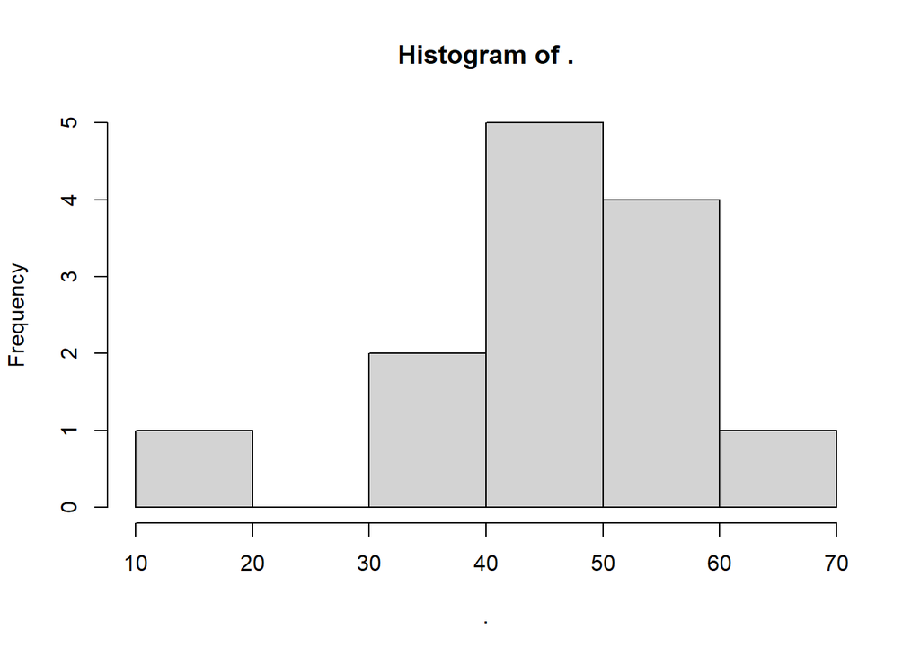

```r
as.numeric(temp[2,]) %>% hist()
```